# APAN Project Proposal - Group 4

# Research Problems

The number of users on Over-The-Top (OTT) platforms has been steadily increasing, reaching 3,507 million users in 2023 according to the research conducted by Statista (Statista Research Department, 2023). However, this growth has also led to a highly competitive landscape among popular platforms such as Netflix, Disney+, and Amazon Prime. The competitive nature of the market is evident from the report by Statista (2023), which indicates a decrease in Netflix’s user growth rate over the years, suggesting the need for platforms to differentiate themselves in terms of content and user experience.

According to a comparative study by R. Sridevi (2023), people in the survey prefer wider range of content and various language choices. In order to understand consumers’ decisions whether to subscribe to OTT platform or not, the research by S. Nagaraj et al found that movie quality which can be referred by the higher rating is one of the five factors significantly influence the decision to retain on the service. Most OTT services are using content-based recommender system based on movie popularity using resources from public reviews such as IMDB (S. Sahu et al., 2022) Considering the proliferation of new OTT platforms and the fact that users tend to subscribe to multiple platforms it is important to know which platform is the best in delivering popular movies and viewers express different tastes in films, it is important to identify which categories have received the highest ratings and understand the factors that drive interest profit rises again.

In addition, when making decisions about which films to watch, viewers often rely on the information presented in the film title or thumbnail (Kauffmann et al., 2019). However, the extent to which the story description influences viewers’ decision-making process remains unclear. Understanding the impact of story content on viewers’ decisions is crucial for OTT platforms to effectively communicate the appeal of their content to potential customers. This research aims to provide valuable insights that will help platforms attract and retain customers by offering more engaging user experiences. Additionally, from the customer’s perspective, this research will analyze the data and determine which platform offers the highest movie ratings, providing guidance on the most worthwhile platform to choose.

# Literature Review

*“Factors affecting consumers’ willingness to subscribe to over-the-top (OTT) video streaming services in India”*

This literature review summarizes a study that focuses on understanding consumers’ decisions whether to subscribe to Over-the-Top (OTT) video streaming services or not. The research aims to identify the factors influencing these subscription decisions and provide insights for OTT service providers by collecting data from 168 participants through snowball sampling and 300 participants through Mturk. Consumers were categorized into three groups based on their subscription preferences. Fourteen reasons for subscribing and eleven reasons for not subscribing to OTT services were identified. Exploratory Factor Analysis revealed five factors, including content, convenience, features, price, and quality. Logistic regression analysis was conducted to examine the impact of these factors and demographic variables on subscription decisions. The findings indicate that all five factors significantly influenced consumers’ decisions, with price having an inverse effect. Household structure emerged as a major influencer, along with age, occupation, and education.

*“Comparative Analysis of Clustering Techniques for Movie Recommendation”*

The paper implemented a movie recommendation system that utilizes clustering algorithms to provide users with a more diverse selection of movies based on their preferences. The study aims to compare different clustering algorithms, including K-means, Agglomerative, Birch, and Mean-shift, in terms of their effectiveness in forming clusters of similar movies. The proposed method focuses on using selective features of the movie dataset and explores the significance and novelty of introducing variety in movie recommendations instead of relying solely on attributes such as cast, director, and genre using k-mean cluster. The results indicate that different algorithms handle stray data points differently and that feature combinations yield varying outputs, allowing users to discover similar movies based on different attributes. Overall, the study highlights the potential of clustering techniques in enhancing movie recommendation systems and accommodating the subjective nature of individual movie preferences.

*“Effects of Emotional State on Decision Making Time”*

The research investigated the effects of emotional states (happiness and sadness) on decision-making time involving first-year college students who watched either a happy or a sad film. Both groups were then asked to answer a set of dilemma questions to test their decision-making process. The findings revealed that individuals who watched a happy film made decisions faster compared to those who watched a sad film, suggesting that sadness can influence decision-making by coloring the content of thoughts and slowing down information processing. On the other hand, individuals in a positive-affect condition demonstrated less confusion in their decision process and engaged in early information processing for decision-making. These results align with theories and concepts from emotion research, highlighting the influence of emotions on decision-making at both individual and group levels.

# Research Questions

- What are the characteristics (Duration, Age Group Restriction, IMDB Rating) of each movie cluster after clustering them?
- Which OTT platform (Netflix, Disney+, Amazon Prime) has the highest proportion of movies on the top IMDB rating cluster?
- Do more positive sentiments used in the movie descriptions (Sentiment Score) have a higher IMDB rating?

# Raw Data

The data we are using for the project was collected from 4 different sources : Disney, Amazon Prime, Netflix and IMDB. There were a total of 6 files; amazon_prime_titles.csv, disney_plus_titles.csv, netflix_title.csv, imdb_ratings.csv, imdb_with_movie_title_and_imdbid_data.csv, and afinn.csv. The raw data files consisted of the list of movies that are on each OTT platform (Netflix, Amazon Prime and Disney Plus) and IMDB movie titles and ratings on a separate file. Afinn.csv was used as a dictionary for sentiment analysis.

# Pre-Processing

The five files had to be merged in order to make a final dataset for analysis. The main goal was to make rows with a single movie title with all the related columns with an imdb rating. The following steps had to be performed in order to make a dataset suitable for our research.

First, the movie titles from Netflix, Amazon Prime and Disney Plus were all merged by movie title. There were movies that were on more than one OTT platforms, thus a column for each OTT platform was created, indicating whether a movie was on its platform or not.

Second, the rating, or the minimum age for watching movies had to be standardized. There were different standards used for different platforms and countries, and these were standardized into categorical variables.

Finally, using the text data of movie description, a sentiment score was calculated. With the positive and negative word dictionary from Affin.csv, a sentiment score for each movie was calculated and added as a column for each movie.

# Variable Description

**movie_title** : Title of movie

**Duration** : Duration of movie, scaled

**min_age_group**: Minimum age to watch the title

**movie_description** : Plot (summary) of movie

**netflix_movie** : 1 if on Netflix, 0 if not

**prime_movie** : 1 if on Amazon Prime, 0 if not

**disney_movie** : 1 if on Disney Plus, 0 if not

**rating** : IMDB rating of movie

**reviewSentiment** : An average sentiment score based on the “afinn” dictionary positive/negative words. Each word has a score depending on the variable.

# Setup

Loading Required packages

```r
rm(list = ls())
library(tidyverse)
library(dplyr)
library(mice)
library(tidytext)
library(ggplot2)
library(scales)
library(ggparliament)
```

## 1. Data sets loading

We have combined 5 different datasets to get the final dataset. The datasets which are involved in the data-preprocessing are: - Amazon.csv (it contains all the movies titles and its corresponding directors, cast, rating, age_group, country (in which it was launched), duration, description, rating, show_id, movie type (movie/tv show or documentary) which are available on prime). - Netflix (it contains all the movies titles and its corresponding directors, cast, rating, age_group, country (in which it was launched), duration, description, rating, show_id, movie type (movie/tv show or documentary) which are available on Netflix).

- Disney+.csv (it contains all the movies titles and its corresponding directors, cast, rating, age_group, country (in which it was launched), duration, description, rating, show_id, movie type (movie/tv show or documentary) which are available on Disney+).
- IMDB_movie_details.csv (it contains the details of the IMDB ID and its corresponding move title)
- IMDB_rating.csv (it contains details of movie titles and its corresponding rating from multiple users)

```r
# Creating netflix data set
netflix_data_set = read_csv("data_sets/netflix_titles.csv")
colnames(netflix_data_set) = paste0("netflix_",colnames(netflix_data_set))
names(netflix_data_set)[names(netflix_data_set) == "netflix_title"] <- "movie_title"

#Mutating "netflix" platform column so that when we combine multiple datasets we will know which movie was screened on which OTT platform
netflix_data_set <- netflix_data_set %>%
  mutate(netflix_movie = "netflix")




#Creating prime data set
prime_data_set = read_csv("data_sets/amazon_prime_titles.csv")
colnames(prime_data_set) = paste0("prime_",colnames(prime_data_set))
names(prime_data_set)[names(prime_data_set) == "prime_title"] <- "movie_title"

#Mutating "prime" platform column so that when we combine multiple datasets we will know which movie was screened on which OTT platform
prime_data_set <- prime_data_set %>%
  mutate(prime_movie = "prime")

#Creating disney data set
disney_data_set = read_csv("data_sets/disney_plus_titles.csv")
colnames(disney_data_set) = paste0("disney_",colnames(disney_data_set))
names(disney_data_set)[names(disney_data_set) == "disney_title"] <- "movie_title"

#Mutating "disney" platform column so that when we combine multiple datasets we will know which movie was screened on which OTT platform
disney_data_set <- disney_data_set %>%
  mutate(disney_movie = "disney")
```

## 2. Merging data sets (netflix, disney, prime)

In here we are merging the data sets of netflix, disney+, and Amazon prime movies by Title using full join. This combined dataset will later be combined with IMDB movie rating dataset to create out final dataset for our analysis.

```r
merged_data <- merge(netflix_data_set, prime_data_set, by = c("movie_title"), all = TRUE)
merged_data = merge(merged_data,disney_data_set, by = c("movie_title"), all = TRUE)
dim(merged_data)
```

```
## [1] 19478    37
```

```r
colnames(merged_data)
```

```
##  [1] "movie_title"          "netflix_show_id"      "netflix_type"
##  [4] "netflix_director"     "netflix_cast"         "netflix_country"
##  [7] "netflix_date_added"   "netflix_release_year" "netflix_rating"
## [10] "netflix_duration"     "netflix_listed_in"    "netflix_description"
## [13] "netflix_movie"        "prime_show_id"        "prime_type"
## [16] "prime_director"       "prime_cast"           "prime_country"
## [19] "prime_date_added"     "prime_release_year"   "prime_rating"
## [22] "prime_duration"       "prime_listed_in"      "prime_description"
## [25] "prime_movie"          "disney_show_id"       "disney_type"
## [28] "disney_director"      "disney_cast"          "disney_country"
## [31] "disney_date_added"    "disney_release_year"  "disney_rating"
## [34] "disney_duration"      "disney_listed_in"     "disney_description"
## [37] "disney_movie"
```

```r
unique(merged_data["netflix_duration"])
```

```
##       netflix_duration
## 1              118 min
## 2               87 min
## 3                 <NA>
## 4              110 min
## 5              128 min
## 6              117 min
## 7              100 min
## 8            2 Seasons
## 11              99 min
## 12              95 min
## 13            1 Season
## 14              90 min
## 15             102 min
## 16             104 min
```

[output cut: 207 more lines]

```r
subset_merged_data = subset(merged_data, select = -c(netflix_show_id, netflix_type, netflix_date_added, netflix_release_year, prime_show_id, prime_type,
prime_date_added, prime_release_year, disney_show_id, disney_type, disney_date_added, disney_release_year))
head(subset_merged_data)
```

```
##          movie_title  netflix_director
## 1                '76        Izu Ojukwu
## 2                '89              <NA>
## 3       'Allo 'Allo!              <NA>
## 4 Kuch Bheege Alfaaz              Onir
## 5        Goli Soda 2      Vijay Milton
## 6    Maj Rati Keteki Santwana Bardoloi
##                                                                                                                                                                                            netflix_cast
## 1 Ramsey Nouah, Rita Dominic, Chidi Mokeme, Ibinabo Fiberesima, Daniel K. Daniel, Memry Savanhu, Adonijah Owiriwa, Pat Nebo, Nelly Ekwereogu, Shuaibu Ebenesi Adams, Debo Oguns, Ben Nwosu, Ada Ofoegbu
## 2                                                                                                                                                                    Lee Dixon, Ian Wright, Paul Merson
## 3                                                                                                                                                                                                  <NA>
## 4                                                         Geetanjali Thapa, Zain Khan Durrani, Shray Rai Tiwari, Mona Ambegaonkar, Chandreyee Ghosh, Barun Chanda, Saheb Bhattacharjee, Shefali Chauhan
## 5                                                                                        Samuthirakani, Bharath Seeni, Vinoth, Esakki Barath, Chemban Vinod Jose, Gautham Menon, Krisha Kurup, Subiksha
## 6                                                            Adil Hussain, Shakil Imtiaz, Mahendra Rabha, Sulakshana Baruah, Rahul Gautam Sarma, Kulada Bhattacharjya, Indu Mohan Das, Moumita Talukdar
##   netflix_country netflix_rating netflix_duration
```

[output cut: 62 more lines]

```r
colnames(subset_merged_data)
```

```
##  [1] "movie_title"         "netflix_director"    "netflix_cast"
##  [4] "netflix_country"     "netflix_rating"      "netflix_duration"
##  [7] "netflix_listed_in"   "netflix_description" "netflix_movie"
## [10] "prime_director"      "prime_cast"          "prime_country"
## [13] "prime_rating"        "prime_duration"      "prime_listed_in"
## [16] "prime_description"   "prime_movie"         "disney_director"
## [19] "disney_cast"         "disney_country"      "disney_rating"
## [22] "disney_duration"     "disney_listed_in"    "disney_description"
## [25] "disney_movie"
```

```r
table(subset_merged_data$disney_rating)
```

```
##
##        G       PG    PG-13    TV-14     TV-G    TV-PG     TV-Y    TV-Y7
##      253      236       66       79      318      301       50      131
## TV-Y7-FV
##       13
```

```r
cbind(subset_merged_data$prime_movie,subset_merged_data$disney_movie, subset_merged_data$netflix_movie)
```

```
##          [,1]    [,2]     [,3]
##     [1,] NA      NA       "netflix"
##     [2,] NA      NA       "netflix"
##     [3,] "prime" NA       NA
##     [4,] NA      NA       "netflix"
##     [5,] NA      NA       "netflix"
##     [6,] NA      NA       "netflix"
##     [7,] NA      NA       "netflix"
##     [8,] NA      NA       "netflix"
##     [9,] "prime" NA       NA
##    [10,] "prime" NA       NA
##    [11,] NA      NA       "netflix"
##    [12,] NA      NA       "netflix"
##    [13,] NA      NA       "netflix"
##    [14,] NA      NA       "netflix"
```

[output cut: 19464 more lines]

## 3. Cleaning the data sets

### **3.1 Cleaning/standardizing “min_age_group”**

```r
modified_rating_subset <- subset_merged_data %>%
  mutate(netflix_rating = ifelse(
    netflix_rating %in% c("74 min", "84 min", "66 min", NA), NA,
    ifelse(netflix_rating == "TV-PG", 10,
    ifelse(netflix_rating == "TV-G", 0,
    ifelse(netflix_rating == "ALL", 0,
    ifelse(netflix_rating == "TV-14", 14,
    ifelse(netflix_rating == "TV-MA", 17,
    ifelse(netflix_rating == "NR", 0,
    ifelse(netflix_rating == "PG-13", 13,
    ifelse(netflix_rating == "TV-Y", 5,
    ifelse(netflix_rating == "R", 17,
    ifelse(netflix_rating == "TV-Y7", 7,
    ifelse(netflix_rating == "PG", 8,
    ifelse(netflix_rating == "G", 0,
    ifelse(netflix_rating == "NC-17", 17,
    ifelse(netflix_rating == "TV-Y7-FV", 7,
    ifelse(netflix_rating == "UR", 0,
    as.integer(netflix_rating)
    )))))))))))))))
  ))

modified_rating_subset <- modified_rating_subset %>%
  mutate(disney_rating = ifelse(
    disney_rating %in% c("74 min", "84 min", "66 min", NA), NA,
    ifelse(disney_rating == "TV-PG", 10,
    ifelse(disney_rating == "TV-G", 0,
    ifelse(disney_rating == "ALL", 0,
    ifelse(disney_rating == "TV-14", 14,
    ifelse(disney_rating == "TV-MA", 17,
    ifelse(disney_rating == "NR", 0,
    ifelse(disney_rating == "PG-13", 13,
    ifelse(disney_rating == "TV-Y", 5,
    ifelse(disney_rating == "R", 17,
    ifelse(disney_rating == "TV-Y7", 7,
    ifelse(disney_rating == "PG", 8,
    ifelse(disney_rating == "G", 0,
    ifelse(disney_rating == "NC-17", 17,
    ifelse(disney_rating == "TV-Y7-FV", 7,
    ifelse(disney_rating == "UR", 0,
    as.integer(disney_rating)
    )))))))))))))))
  ))

modified_rating_subset <- modified_rating_subset %>%
  mutate(prime_rating = ifelse(
    prime_rating %in% c("74 min", "84 min", "66 min", NA), NA,
    ifelse(prime_rating == "TV-PG", 10,
    ifelse(prime_rating == "TV-G", 0,
    ifelse(prime_rating == "ALL", 0,
    ifelse(prime_rating == "TV-14", 14,
    ifelse(prime_rating == "TV-MA", 17,
    ifelse(prime_rating == "NR", 0,
    ifelse(prime_rating %in% c("13+", "PG-13"), 13,
    ifelse(prime_rating == "TV-Y", 5,
    ifelse(prime_rating %in% c("R", "TV-MA", "NC-17", "AGES_18_", "18+"), 17,
    ifelse(prime_rating %in% c("TV-PG", "7+", "TV-Y", "TV-Y7"), 7,
    ifelse(prime_rating == "PG", 8,
    ifelse(prime_rating %in% c("ALL", "TV-G", "G", "UNRATED", "TV-NR", "NR", "ALL_AGES", "NOT_RATE", "UR"), 0,
    ifelse(prime_rating %in% c("16+", "AGES_16_", "16"), 16,
    ifelse(prime_rating == "TV-Y7-FV", 7,
    ifelse(prime_rating == "UR", 0,
    as.integer(prime_rating)
    )))))))))))))))))

# printing out the unique min_age_group to see if there are anything missed out
unique(modified_rating_subset$prime_rating)
```

```
##  [1] NA 13 16  0 10 17 14  7  8  5
```

```r
unique(modified_rating_subset$disney_rating)
```

```
## [1] NA 13  7  0 10  8 14  5
```

```r
unique(modified_rating_subset$netflix_rating)
```

```
## [1] 10 NA 14 17  0 13  5  7  8
```

```r
# combining the data together under one column.
modified_rating_subset <- modified_rating_subset %>%
  mutate(prime_rating = coalesce(prime_rating, disney_rating, netflix_rating))

# since we have got all the movie ratings under one column we will be removing the other ratings column
rating_unified_subset = subset(modified_rating_subset, select = -c(netflix_rating,disney_rating))
colnames(rating_unified_subset)
```

```
##  [1] "movie_title"         "netflix_director"    "netflix_cast"
##  [4] "netflix_country"     "netflix_duration"    "netflix_listed_in"
##  [7] "netflix_description" "netflix_movie"       "prime_director"
## [10] "prime_cast"          "prime_country"       "prime_rating"
## [13] "prime_duration"      "prime_listed_in"     "prime_description"
## [16] "prime_movie"         "disney_director"     "disney_cast"
## [19] "disney_country"      "disney_duration"     "disney_listed_in"
## [22] "disney_description"  "disney_movie"
```

```r
# changing the name of the oclum to min_age_group
names(rating_unified_subset)[names(rating_unified_subset) == "prime_rating"] <- "min_age_group"

rating_unified_subset$min_age_group=as.character(rating_unified_subset$min_age_group)
rating_unified_subset$min_age_group=as.factor(rating_unified_subset$min_age_group)
```

### **3.2 Cleaning “duration”**

In this we will be cleaning the duration column. The duration column consists of numeric along with character data. For example it has 198 min, 100 min, or 2 seasons etc.. So in this section we have extracted only the numeric data from it and cleaned the column.

```r
# Cleaning Duration
unified_duration = rating_unified_subset %>% mutate(prime_duration = coalesce(prime_duration, netflix_duration, disney_duration))
table(unified_duration[,"prime_duration"])
```

```
##
##      0 min      1 min   1 Season     10 min 10 Seasons    100 min    101 min
##         10         10       3295         25         14        234        222
##    102 min    103 min    104 min    105 min    106 min    107 min    108 min
##        225        222        207        207        204        177        150
##    109 min     11 min 11 Seasons    110 min    111 min    112 min    113 min
##        152         12          5        159        140        130        125
##    114 min    115 min    116 min    117 min    118 min    119 min     12 min
##        111        101        123        106        116        102         13
## 12 Seasons    120 min    121 min    122 min    123 min    124 min    125 min
##          5        120         84         91         78         75         80
##    126 min    127 min    128 min    129 min     13 min 13 Seasons    130 min
##         79         88         64         65         14          2         61
##    131 min    132 min    133 min    134 min    135 min    136 min    137 min
##         69         68         77         40         67         56         63
```

[output cut: 58 more lines]

```r
# combining the data together under one column.
unified_duration = subset(unified_duration, select = -c(netflix_duration,disney_duration))
names(unified_duration)[names(unified_duration) == "prime_duration"] <- "duration"

# cleaning up seasons data
unified_duration <- unified_duration[!grepl("Season", unified_duration$duration), ]
unified_duration$duration = parse_number(unified_duration$duration)
```

### **3.3 Cleaning “description”**

The description column has data about the movie, like the summary of the movie. Some movies are telecast-ed in some OTT platforms and may not be one Disney+, so the row data for the Disney+ will NA. So as process of cleaning the data, will be gathering description of the movie column under one column.

```r
# cleaning up Movie Description by combining them into one column
unified_description <- unified_duration %>%
  mutate(prime_description = coalesce(netflix_description, disney_description, prime_description))

# removing the remaining fields as their data is already combined into one single column.
unified_description = subset(unified_description, select = -c(netflix_description,disney_description))
names(unified_description)[names(unified_description) == "prime_description"] <- "movie_description"
```

### **3.4 Cleaning “listed_in” (movie/genre type)**

The genre column has data about the movie category, like if the movie is drama or action etc… Some movies are telecast-ed in some OTT platforms and may not be one Disney+, so the row data for the Disney+ will NA. So as process of cleaning the data, will be gathering genre type of the movie column under one column.

```r
# cleaning listed in (category of the movie/genre type) by combining them into one column
unified_category <- unified_description %>%
  mutate(disney_listed_in = coalesce(netflix_listed_in, prime_listed_in, disney_listed_in))

# removing the remaining fields as their data is already combined into one single column.
unified_category = subset(unified_category, select = -c(netflix_listed_in,prime_listed_in))
names(unified_category)[names(unified_category) == "disney_listed_in"] <- "movie_category"
```

### **3.5 Subset of relevant columns**

Here we will be subsetting the required columns which are required for our final dataset which is then used for our further analysis to answer our research questions.

```r
# Subsetting only the required columns which are required for our final dataset.
unified_category <- subset(unified_category, select= c( movie_title,min_age_group, duration, movie_description, netflix_movie, prime_movie, disney_movie))
```

## 4. Creating SentimentScore (positive/negative)

In this we will be creating sentiment score for description of the Movie. In this we will be using the sentiment algorithm on the movie plot and then derive the score based on the movie plot. This scores are later correlated with the IMDB rating which will help us to answer the research question “whether positive movies have more IMDB rating?”

```r
#Reading afinn(sentiments) dictionary
afinn = read.csv('data_sets/Afinn.csv')

#Getting mean/average sentiment score by movie_title
sentiment_data = unified_category %>%
  select(movie_title,movie_description)%>%
  group_by(movie_title)%>%
  unnest_tokens(output=word,input=movie_description)%>%
  inner_join(afinn)%>%
   summarize(reviewSentiment = mean(value))
#Joining sentiment_data with all data (unified_category)
unified_category = left_join(unified_category, sentiment_data, by = "movie_title")

#Counting NA values for sentiment
sum(is.na(unified_category$reviewSentiment))
```

```
## [1] 2003
```

```r
colnames(unified_category)
```

```
## [1] "movie_title"       "min_age_group"     "duration"
## [4] "movie_description" "netflix_movie"     "prime_movie"
## [7] "disney_movie"      "reviewSentiment"
```

## 5. Merging IMDB data

Here we will be pre-processing data from 2 different IMDB data sets and we will be merging these 2 data sets. These datasets are described as follows: - imdb_with_movie_title_and_imdbid_data.tsv (it contains the details of the IMDB ID and its corresponding move title)

- imdb_rating_data.tsv (it contains details of movie titles, movie type(movie or tvmovie or tvseries) and its corresponding rating from multiple users)

As part of data preprocessing we will verify if there are any anomalies in the dataset and do data cleaning as required.

The following procedure is followed as part of data pre-processing of IMDB data:

- Reading imdb_rating_data.tsv and imdb_with_movie_title_and_imdbid_data.tsv files
- Filtering only movies and series data followed by then sub-setting imdb_ids and corresponding movie titles
- We then combine both the dataframes imdb_titles and imdb_rating using left_join by using tconst (which is the unique ID)
- Later will take the average of multiple rating if given by user for the same movie multiple times and then averaging them to get the rating for the movie. For missing rating we later imputed the required values.
- After that we will be Sub-setting the data frame with the required columns “title” and “rating” which will later be used to combine with the data frame (which contains the movies from OTT platforms)
- Later we will be Merging IMD_Final data frame with that of the movie data set

```r
#Read imdb rating
imdb_rating<- read.delim("data_sets/imdb_rating_data.tsv", sep = "\t")
head(imdb_rating)
```

```
##      tconst averageRating numVotes
## 1 tt0000001           5.7     1983
## 2 tt0000002           5.8      265
## 3 tt0000003           6.5     1839
## 4 tt0000004           5.5      178
## 5 tt0000005           6.2     2623
## 6 tt0000006           5.1      182
```

```r
#Loading imdb titles data
imdb_data1 <- read.delim("data_sets/imdb_with_movie_title_and_imdbid_data.tsv", sep = "\t")
head(imdb_data1)
```

```
##      tconst titleType           primaryTitle          originalTitle isAdult
## 1 tt0000001     short             Carmencita             Carmencita       0
## 2 tt0000002     short Le clown et ses chiens Le clown et ses chiens       0
## 3 tt0000003     short         Pauvre Pierrot         Pauvre Pierrot       0
## 4 tt0000004     short            Un bon bock            Un bon bock       0
## 5 tt0000005     short       Blacksmith Scene       Blacksmith Scene       0
## 6 tt0000006     short      Chinese Opium Den      Chinese Opium Den       0
##   startYear endYear runtimeMinutes                   genres
## 1      1894     \\N              1        Documentary,Short
## 2      1892     \\N              5          Animation,Short
## 3      1892     \\N              4 Animation,Comedy,Romance
## 4      1892     \\N             12          Animation,Short
## 5      1893     \\N              1             Comedy,Short
## 6      1894     \\N              1                    Short
```

```r
#Filtering in only movies and series
imdb_data1 <- imdb_data1 %>%
  filter(titleType %in% c("movie", "tvMovie", "tvSeries"))


#Filtering imdb titles
imdb_titles <- imdb_data1[c("tconst", "primaryTitle")]
head(imdb_titles)
```

```
##      tconst                  primaryTitle
## 1 tt0000009                    Miss Jerry
## 2 tt0000147 The Corbett-Fitzsimmons Fight
## 3 tt0000502                      Bohemios
## 4 tt0000574   The Story of the Kelly Gang
## 5 tt0000591              The Prodigal Son
## 6 tt0000615            Robbery Under Arms
```

```r
#Joining imdb datasets
imdb_final_combine = left_join(imdb_titles, imdb_rating, by = "tconst")
colnames(imdb_final_combine)
```

```
## [1] "tconst"        "primaryTitle"  "averageRating" "numVotes"
```

```r
dim(imdb_final_combine)
```

```
## [1] 1037931       4
```

```r
# checking the number of rows
nrow(imdb_final_combine)
```

```
## [1] 1037931
```

```r
sum(!complete.cases(imdb_final_combine))
```

```
## [1] 605261
```

```r
sum(complete.cases(imdb_final_combine))
```

```
## [1] 432670
```

```r
# values <- c(sum(!complete.cases(imdb_final_combine)),sum(complete.cases(imdb_final_combine)))
#
# # Define the labels for each value
# labels <- c("rows with no NA values", "rows with NA values")
#
# # Create the pie chart
# pie(values,labels = sprintf("%s\n(%s)", labels, percent(values/sum(values))), main="Percentage of NA rows before imputation")

#Taking the average/mean rating for titles with multiple ratings
imdb_final <- imdb_final_combine %>%
  select(primaryTitle, averageRating, tconst) %>%
  group_by(primaryTitle) %>%
  summarize(rating = mean(averageRating, na.rm = T))
dim(imdb_final)
```

```
## [1] 886414      2
```

```r
colSums(is.na(imdb_final))
## primaryTitle       rating
##            0       506941
# imputing missing values in rating
imdb_final = complete(mice(imdb_final, method = "pmm"))
#number of NA ratings after imputation
sum(!complete.cases(imdb_final))
```

```
## [1] 0
```

```r
#Selecting 'title' and 'rating'
imdb_final = imdb_final%>% select (movie_title=primaryTitle,rating)

#Merging merged dataset and imdb data
merged_data_imdb = left_join(unified_category, imdb_final, by = "movie_title")
colnames(merged_data_imdb)
```

```
## [1] "movie_title"       "min_age_group"     "duration"
## [4] "movie_description" "netflix_movie"     "prime_movie"
## [7] "disney_movie"      "reviewSentiment"   "rating"
```

## 6. Final Step of data cleaning

```r
#Deleting all titles with NA ratings
final_imdb_data <- merged_data_imdb
#Rounding rating to one decimal
final_imdb_data = final_imdb_data%>%mutate(rating = round(rating, 1))

# converting the categorical variables to numeric. 1- means the movie is telecasted on that perticular OTT platform, 0 means it is not telecasted on the corresponding OTT platform.
final_imdb_data = final_imdb_data %>% mutate(prime_movie = if_else(prime_movie == "prime", 1, 0))
final_imdb_data = final_imdb_data %>% mutate(disney_movie = if_else(disney_movie == "disney", 1, 0))
final_imdb_data = final_imdb_data %>% mutate(netflix_movie = if_else(netflix_movie == "netflix", 1, 0))

# subsetting the data frame with the required columns which we need for our analysis
final_imdb_data = final_imdb_data %>% select(movie_title,min_age_group, duration, movie_description, netflix_movie, prime_movie, disney_movie, rating, reviewSentiment)

# If there are ny NAs found under the OTT platform column names we will consider that the movie is not te
final_imdb_data$prime_movie[is.na(final_imdb_data$prime_movie)] <- 0
final_imdb_data$disney_movie[is.na(final_imdb_data$disney_movie)] <- 0
final_imdb_data$netflix_movie[is.na(final_imdb_data$netflix_movie)] <- 0
# imputing missing values for age group, rating, duration
final_imdb_data <- complete(mice(data = final_imdb_data, method = "pmm"))
# checking the final column names
colnames(final_imdb_data)
# checking the data
head(final_imdb_data)
# checking if there are any na values on the final dataset
colSums(is.na(final_imdb_data))

# scaling the rating and duration data
final_imdb_data$rating = scale(final_imdb_data$rating)
final_imdb_data$duration = scale(final_imdb_data$duration)
# final_imdb_data$rating
```

[output not shown]

## 7.Exploring Dataset

Here we are exploring our final data set which we have derived by combining 5 different dataset and after utilizing multiple pre-processing techniques

```r
# Total rows
nrow(final_imdb_data)
```

```
## [1] 14671
```

```r
# Proportion of movies per platform
netflix = final_imdb_data[final_imdb_data$netflix_movie==1,]
nrow(netflix)
```

```
## [1] 6150
```

```r
prime = final_imdb_data[final_imdb_data$prime_movie==1,]
nrow(prime)
```

```
## [1] 7814
```

```r
disney = final_imdb_data[final_imdb_data$disney_movie==1,]
nrow(disney)
```

```
## [1] 1051
```

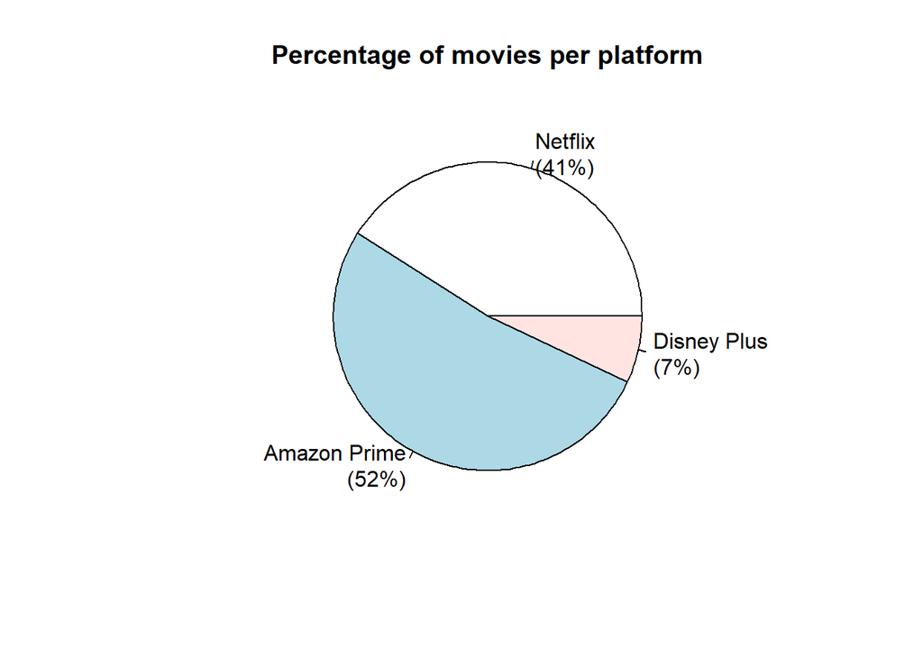

```r
values <- c(6150,7814,1051)

# Define the labels for each value
labels <- c("Netflix", "Amazon Prime", "Disney Plus")

# Create the pie chart
pie(values,labels = sprintf("%s\n(%s)", labels, percent(values/sum(values))), main='Percentage of movies per platform')
```

# Exporting data as csv

Finally the final dataset is exported to a csv file

```r
write.csv(final_imdb_data, "group4_final_data.csv", row.names = FALSE)
```

# References

Aditya, T. S., Rajaraman, K., & Subashini, M. M. (2018). Comparative Analysis of Clustering Techniques for Movie Recommendation. MATEC Web Conf., 225, 02004. https://doi.org/10.1051/matecconf/201822502004.

Duque, M. J., Turla, C., & Evangelista, L. (2013). Effects of emotional state on decision making time. Procedia - Social and Behavioral Sciences, 97, 137-146. ISSN 1877-0428. https://www.sciencedirect.com/science/article/pii/S1877042813036598

Kauffmann, Peral, Gil, Ferrández, Sellers, & Mora. (2019). Managing Marketing Decision-Making with Sentiment Analysis: An Evaluation of the Main Product Features Using Text Data Mining. Sustainability, 11(15), 4235. MDPI AG. http://dx.doi.org/10.3390/su11154235

Netflix. (April 18, 2023). Number of Netflix paid subscribers worldwide from 1st quarter 2013 to 1st quarter 2023 (in millions) [Graph]. In Statista. Retrieved July 09, 2023, from https://www-statista-com.ezproxy.cul.columbia.edu/statistics/250934/quarterly-number-of-netflix-streaming-subscribers-worldwide/

Sahu, S., Kumar, R., Pathan, M. S., Shafi, J., Kumar, Y., & Ijaz, M. F. (2022). Movie Popularity and Target Audience Prediction Using the Content-Based Recommender System. IEEE Access, 10, 42044-42060. doi: 10.1109/ACCESS.2022.3168161 (https://ieeexplore.ieee.org/abstract/document/9758691)

Samala Nagaraj, Soumya Singh, and Venkat Reddy Yasa. (2021). Factors affecting consumers’ willingness to subscribe to over-the-top (OTT) video streaming services in India. Technology in Society, 65, 101534. ISSN 0160-791X. https://www.sciencedirect.com/science/article/pii/S0160791X21000099

Statista. (June 26, 2023). Number of users of OTT video worldwide from 2018 to 2027 (in millions) [Graph]. In Statista. Retrieved July 09, 2023, from https://www-statista-com.ezproxy.cul.columbia.edu/forecasts/1207843/ott-video-users-worldwide